# ETC3250/5250 Introduction to Machine Learning

## Diagnoing Convergence

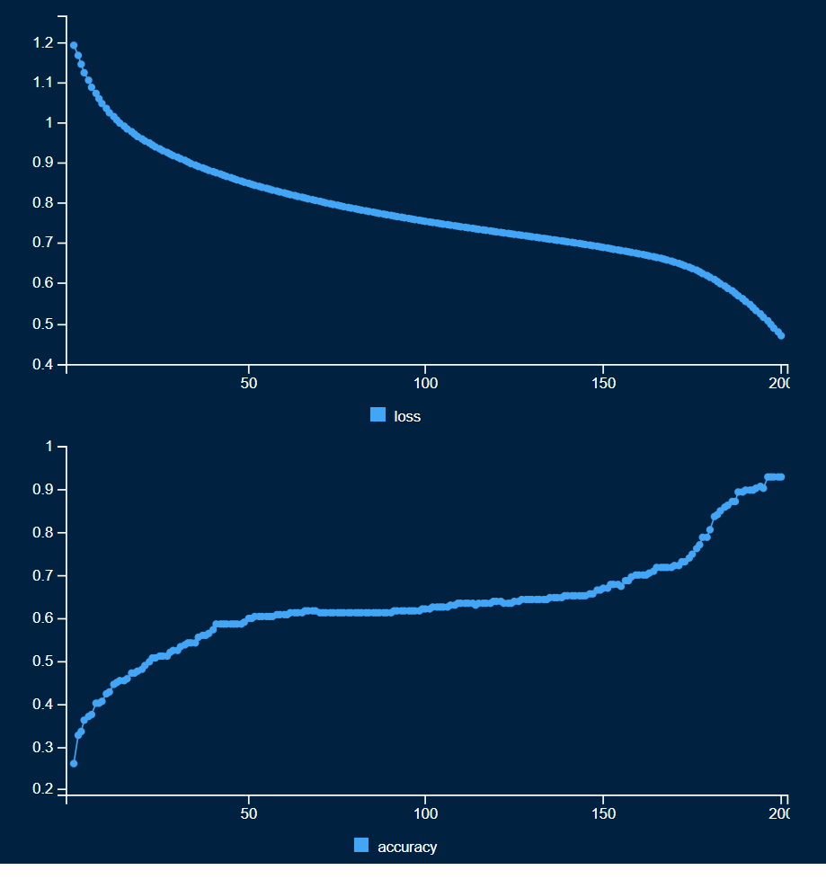

## Diagnoing Convergence

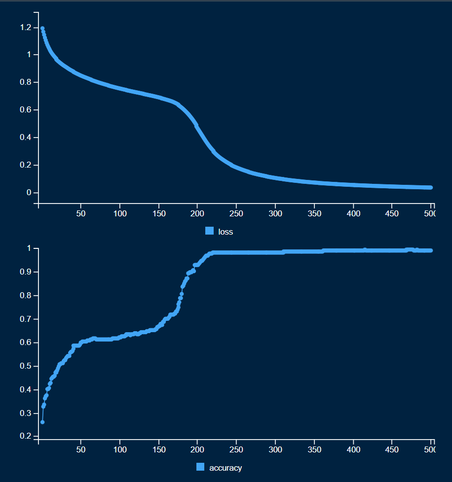

## Example: penguins (4/5)

Evaluate the fit

```r
p_nn_model |>
  evaluate(p_test_x, p_test_y, verbose = 0)
```

```
$accuracy
[1] 0.8

$loss
[1] 0.63
```

Confusion matrices for training and test

```
           p_train_pred_cat
            Adelie Chinstrap Gentoo
  Adelie        96         3      1
  Chinstrap      2        43      0
  Gentoo        38         0     44
```

```
           p_test_pred_cat
            Adelie Chinstrap Gentoo
  Adelie        49         2      0
  Chinstrap      0        23      0
  Gentoo        20         1     20
```

Really good practice to look at both training and testing error here

Note: Specifically have chosen settings so fit is not perfect - This NN’s training had not converged!

Estimated parameters

```r
# Extract hidden layer model weights
p_nn_wgts <- keras3::get_weights(p_nn_model, trainable=TRUE)
p_nn_wgts
```

```
[[1]]
      [,1]  [,2]
[1,]  0.63  1.36
[2,]  0.17  0.08
[3,] -0.11 -0.30
[4,] -0.77 -0.24

[[2]]
[1]  0.118 -0.045

[[3]]
      [,1] [,2]  [,3]
[1,] -0.36  1.4 -1.73
[2,] -0.85  1.1  0.38

[[4]]
[1]  0.70 -0.90  0.58
```

Which variables are contributing most to each hidden layer node?

Can you write out the model?

## Example: penguins (5/5)

The values outputed by the hidden layer nodes are the *learned* engineered features.

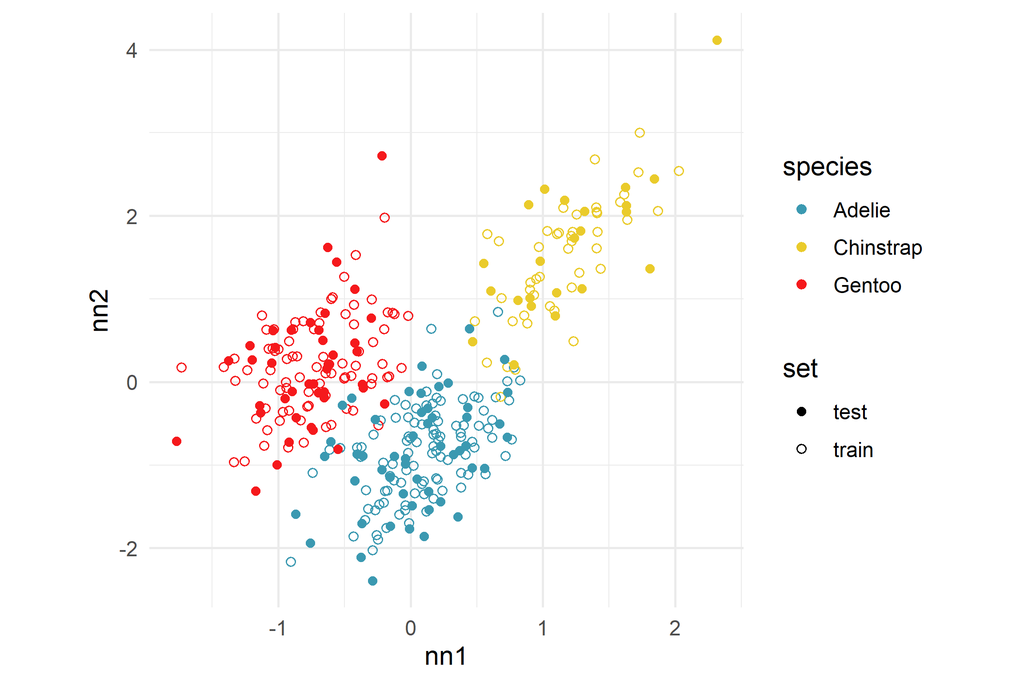

This is the dimension reduction induced by the model.

Realistically, with a complex neural network, it is too much work to check these nodes.

Examine the predictive probabilities

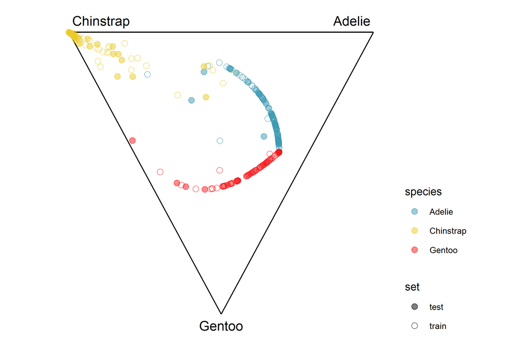

The problem with this model is that Gentoo are too confused with Adelie. This is a structural problem because from the visualisation of the 4D data we know that there is a big gap between the Gentoo and both other species.

## Deciding on a Architecture

Ideally, you would learn the model hyperparameters (#Hidden layer, #Nodes and activations) via cross-validation (as we did with trees)

This was feasible for trees as they were fast and easy to fit

NN’s are slow and complicated to fit

I would advise hand tuning them by cross-validation i.e. do cross-validation but rather than trying a huge grid like we did with DTs, gradually make the model more complex.

- Stick to ReLU activations
- Start with a small number of nodes and train till convergence
  - keep track of in- and out-of-sample errors
- Increase the number of nodes
  - make sure the in-sample errors go down (if not you either need more training iterations or a new starting point)
  - Hopefully the out-of-sample error goes down too (if not you are overfitting)
- Consider adding another hidden layer and repeat

## Deciding on a Architecture

Ideally, you would learn the model hyperparameters (#Hidden layer, #Nodes and activations) via cross-validation (as we did with trees)

This was feasible for trees as they were fast and easy to fit

NN’s are slow and complicated to fit

I would advise hand tuning them by cross-validation i.e. do cross-validation but rather than trying a huge grid like we did with DTs, gradually make the model more complex.

Ideally the number of hidden nodes is greater than the numebr of predictors, the idea is to embed the predictors in a high dimensional space where they will be easier to classify.

But with many hidden nodes it is very easy to overfit!

## Want to learn more?

- Take ETC3555/ETC5555 Statistical Machine Learning
  - We cover foundationation so Neural Network
  - Algorithms for learning their parameters
  - Ways to prevent overfitting
  - Extensions to image classification and text analysis
- Work your way through the example of fitting the [fashion MNIST data](https://tensorflow.rstudio.com/tutorials/keras/classification) using tensorflow.
- [Hands-on machine learning](https://bradleyboehmke.github.io/HOML/deep-learning.html) has a lovely step-by-step guide to constructing and fitting.
- This is a very nice slide set: [A gentle introduction to deep learning in R using Keras](https://lnalborczyk.github.io/slides/vendredi_quanti_2021/vendredi_quantis#1)
- And the tutorials at [TensorFlow for R](https://tensorflow.rstudio.com/install/) have lots of examples.

## Image Data

Neural Networks have been shown to have excellent performance in image classification e.g.

- Does this image contain a cat or a dog?
- Which number between 0 and 9 is this?

However, image data doesn’t quite look like the normal predictor $x\in\mathbb{R}^p$ that we are now used to see

Well actually they do…

```r
mnist<-dataset_mnist()
tri<-train_images<-mnist$train$x
train_labels<-mnist$train$y
tri[1,,]
```

```
      [,1] [,2] [,3] [,4] [,5] [,6] [,7] [,8] [,9] [,10]
 [1,]    0    0    0    0    0    0    0    0    0     0
 [2,]    0    0    0    0    0    0    0    0    0     0
 [3,]    0    0    0    0    0    0    0    0    0     0
 [4,]    0    0    0    0    0    0    0    0    0     0
 [5,]    0    0    0    0    0    0    0    0    0     0
 [6,]    0    0    0    0    0    0    0    0    0     0
 [7,]    0    0    0    0    0    0    0    0   30    36
 [8,]    0    0    0    0    0    0    0   49  238   253
 [9,]    0    0    0    0    0    0    0   18  219   253
[10,]    0    0    0    0    0    0    0    0   80   156
[11,]    0    0    0    0    0    0    0    0    0    14
[12,]    0    0    0    0    0    0    0    0    0     0
[13,]    0    0    0    0    0    0    0    0    0     0
[14,]    0    0    0    0    0    0    0    0    0     0
```

[output cut: 72 more lines]

## Image Data

[figure not shown]

```r
plot(as.raster(tri[1,,],max=255))
```

## Next: Explainable artificial intelligence (XAI)

ETC3250/5250 Lecture 6